Volver al inicio

# Unidad 3. Análisis y representación de datos categóricos

## ANOVA a 1 factor

Ahora vamos a trabajar con los datos con variables categóricas. Cuando incorporamos un factor con diferentes niveles y nos interesa comparar si hay diferencias entre los efectos de los distintos niveles de uno o más factores uno de los análisis más utilizados es el análisis de la varianza. Comenzaremos con el caso de un único factor.

Este análisis plantea la comparación de medias muestrales a partir de la varianza que presentan los datos dentro de cada grupo (de allí su nombre). Al igual que el modelo de regresión, presenta supuestos a cumplirse (normalidad de la variable y homogeneidad de las varianzas).

El planteo del modelo en R será de la misma manera que la regresión, ya que se trata de otro modelo lineal. En nuestro ejemplo trabajaremos evaluando el efecto del estrés térmico (inicialmente) en el peso seco de semillas de la variedad Alim 3,14. Para ello armaremos la base de datos (doy como ejemplo algunas formas de armarla en base a las que ya tenemos):

```r
SEM_Alim <- SEM %>% filter(GT == "Alim 3,14")
SEM_Alim <- ALIM %>% filter(Organo == "Semilla")
SEM_Alim <- ALIM_VyS %>% filter(Organo == "Semilla")
SEM_Alim <- ALIM_VyS %>% filter(Organo != "Vaina") # signo diferente a
```

Y ahora sí corremos el modelo y ponemos a prueba los supuestos de igual manera que hiciéramos anteriormente:

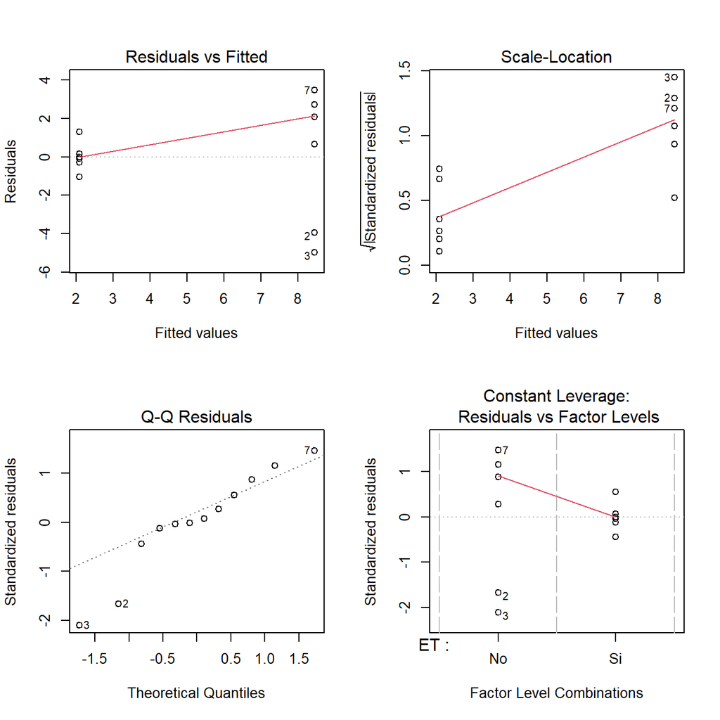

```r
fit3 <-lm(PS ~ ET, data = SEM_Alim)

# Gráfico de supuestos
layout(matrix(1:4, 2, 2)); plot(fit3) ;layout(1)
```

```r
shapiro.test(resid(fit3))
```

```
##
##  Shapiro-Wilk normality test
##
## data:  resid(fit3)
## W = 0.92632, p-value = 0.3428
```

```r
bartlett.test(resid(fit3)~SEM_Alim$ET) # no hay homogeneidad
```

```
##
##  Bartlett test of homogeneity of variances
##
## data:  resid(fit3) by SEM_Alim$ET
## Bartlett's K-squared = 8.139, df = 1, p-value = 0.004332
```

Como vemos hay normalidad de errores pero no homogeneidad de varianza. Si bien esto pudiera no ser un problema muy grande (el modelo sobreestimará la varianza general y tendrá menos potencia), podemos transformar la variable respuesta:

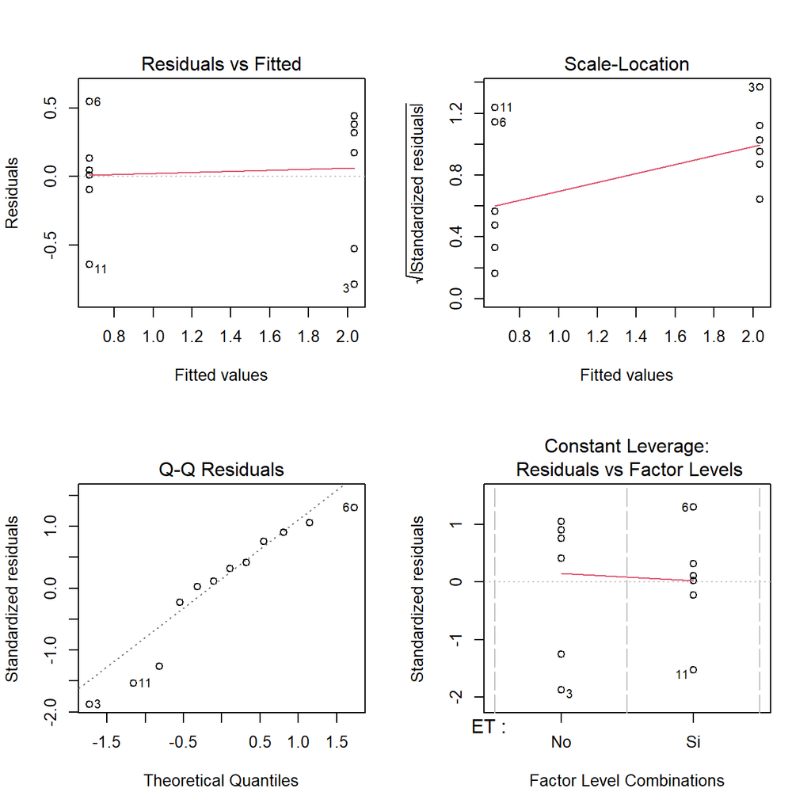

```r
# Probamos transformando por el logaritmo
fit3 <-lm(log(PS) ~ ET, data = SEM_Alim)

layout(matrix(1:4, 2, 2)); plot(fit3) ;layout(1)
```

```r
shapiro.test(resid(fit3))
```

```
##
##  Shapiro-Wilk normality test
##
## data:  resid(fit3)
## W = 0.91186, p-value = 0.2254
```

```r
bartlett.test(resid(fit3)~SEM_Alim$ET)
```

```
##
##  Bartlett test of homogeneity of variances
##
## data:  resid(fit3) by SEM_Alim$ET
## Bartlett's K-squared = 0.41623, df = 1, p-value = 0.5188
```

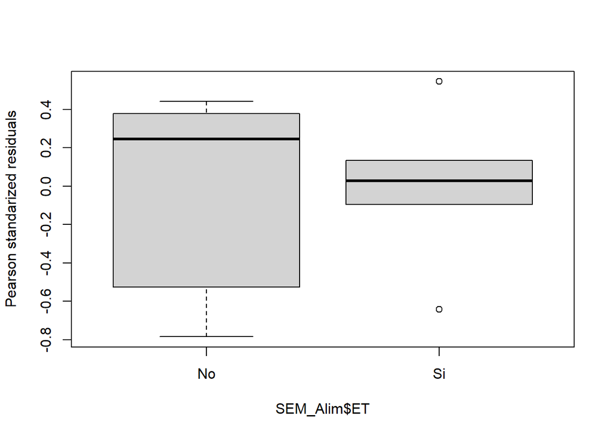

```r
boxplot(residuals(fit3,type="pearson")~SEM_Alim$ET,
      ylab="Pearson standarized residuals")
```

```r
# ahora sí se cumple
```

Entonces ahora que ya sabemos de la validez del modelo, pediremos la tabla del ANOVA para ver si existen o no diferencias significativas:

```r
anova(fit3)
```

```
## Analysis of Variance Table
##
## Response: log(PS)
##           Df Sum Sq Mean Sq F value    Pr(>F)
## ET         1 5.5709  5.5709  26.502 0.0004327 ***
## Residuals 10 2.1020  0.2102
## ---
## Signif. codes:  0 '***' 0.001 '**' 0.01 '*' 0.05 '.' 0.1 ' ' 1
```

Vemos que arroja un p mucho menor a 0,05, por lo que diremos que al menos una media es diferente de las otras (como en este caso son dos niveles, una de la otra). Para saber cuál es diferente de cuál, como test a posteriori podemos correr el test de Tukey. Para ello utilizamos la función `HSD.test` del paquete **agricolae**:

```r
# Tukey
tukey1 <- HSD.test(fit3,"ET")
tukey1$groups
```

```
##      log(PS) groups
## No 2.0346143      a
## Si 0.6719101      b
```

Vemos que sin estrés térmico las semillas tenían mayor peso seco.

## ANOVA bifactorial

Para correr un modelo de ANOVA con 2 factores diferentes y evaluar su interacción debemos poner ambas variables separadas por *. Analizaremos el mismo modelo de antes pero incorporando además el efecto del CO<sub>2</sub> atmosférico:

```r
SEM_Alim$CO2 <- as.factor(SEM_Alim$CO2) # convertimos a factor
fit4 <-lm(PS ~ ET*CO2, data = SEM_Alim)
```

De la misma manera que antes, probamos los supuestos:

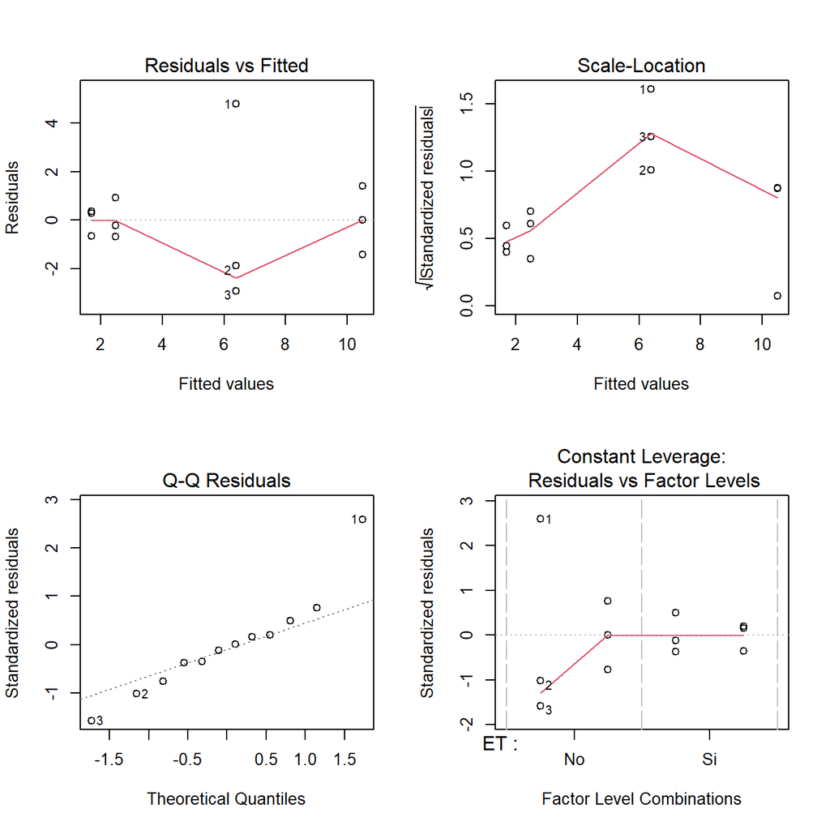

```r
# Gráfico de supuestos
layout(matrix(1:4, 2, 2)); plot(fit4) ;layout(1)
```

```r
# la homogeneidad se prueba para cada factor
bartlett.test(resid(fit4)~SEM_Alim$ET)
```

```
##
##  Bartlett test of homogeneity of variances
##
## data:  resid(fit4) by SEM_Alim$ET
## Bartlett's K-squared = 7.6109, df = 1, p-value = 0.005802
```

```r
bartlett.test(resid(fit4)~SEM_Alim$CO2)
```

```
##
##  Bartlett test of homogeneity of variances
##
## data:  resid(fit4) by SEM_Alim$CO2
## Bartlett's K-squared = 4.1568, df = 1, p-value = 0.04147
```

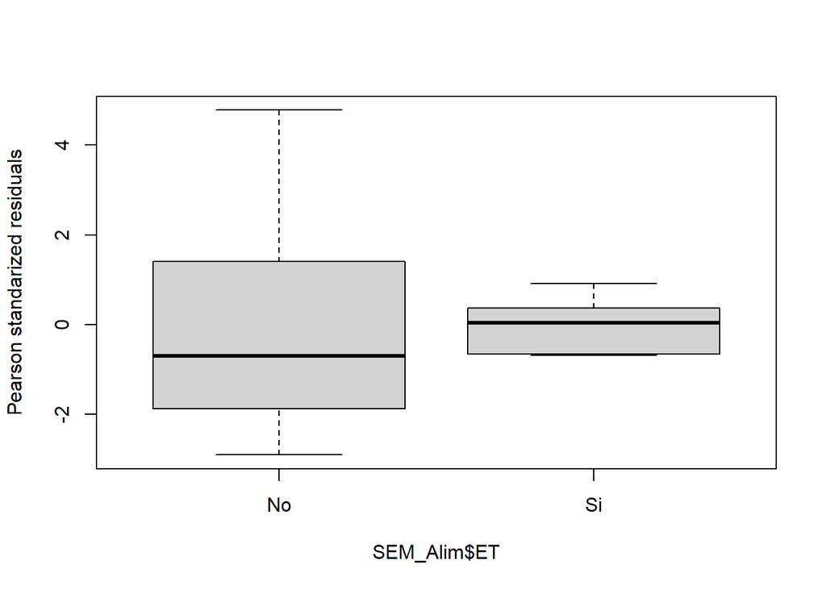

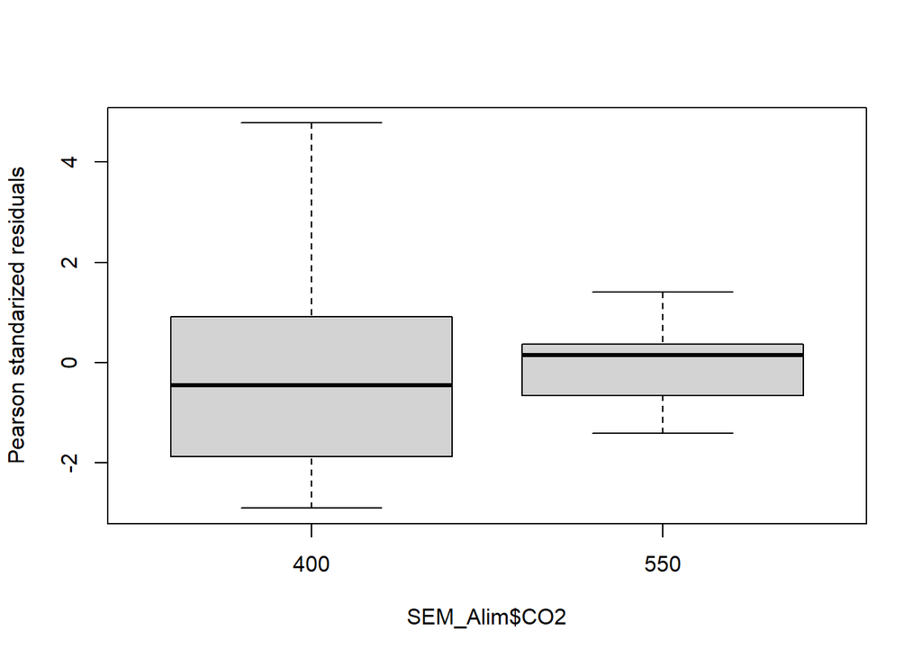

```r
boxplot(residuals(fit4,type="pearson")~SEM_Alim$ET,
        ylab="Pearson standarized residuals")
boxplot(residuals(fit4,type="pearson")~SEM_Alim$CO2,
        ylab="Pearson standarized residuals")
```

```r
# Tablas
anova(fit4)
```

```
## Analysis of Variance Table
##
## Response: PS
##           Df Sum Sq Mean Sq F value   Pr(>F)
## ET         1 121.73 121.731 23.9217 0.001207 **
## CO2        1   8.30   8.300  1.6311 0.237373
## ET:CO2     1  17.91  17.910  3.5195 0.097500 .
## Residuals  8  40.71   5.089
## ---
## Signif. codes:  0 '***' 0.001 '**' 0.01 '*' 0.05 '.' 0.1 ' ' 1
```

```r
summary(fit4)
```

```
##
## Call:
## lm(formula = PS ~ ET * CO2, data = SEM_Alim)
##
## Residuals:
##     Min      1Q  Median      3Q     Max
## -2.9033 -0.8675 -0.1083  0.5008  4.7767
##
## Coefficients:
##             Estimate Std. Error t value Pr(>|t|)
## (Intercept)    6.393      1.302   4.909  0.00118 **
## ETSi          -3.927      1.842  -2.132  0.06560 .
## CO2550         4.107      1.842   2.230  0.05633 .
## ETSi:CO2550   -4.887      2.605  -1.876  0.09750 .
## ---
## Signif. codes:  0 '***' 0.001 '**' 0.01 '*' 0.05 '.' 0.1 ' ' 1
##
## Residual standard error: 2.256 on 8 degrees of freedom
## Multiple R-squared:  0.7842, Adjusted R-squared:  0.7033
## F-statistic: 9.691 on 3 and 8 DF,  p-value: 0.004853
```

Vemos que el resultado del ANOVA es significativo únicamente para el factor ET, por lo que el modelo correcto sería el unifactorial. Sin embargo mostraremos los test a posteriori para el caso bifactorial:

```r
tukey1 <- HSD.test(fit4,"ET")
tukey1$groups
```

```
##          PS groups
## No 8.446667      a
## Si 2.076667      b
```

```r
tukey2 <- HSD.test(fit4,"CO2")
tukey2$groups
```

```
##           PS groups
## 550 6.093333      a
## 400 4.430000      a
```

```r
tukey3 <- HSD.test(fit4,c("ET","CO2"))
tukey3$groups
```

```
##               PS groups
## No:550 10.500000      a
## No:400  6.393333     ab
## Si:400  2.466667      b
## Si:550  1.686667      b
```

## Actividad 4

Realice un ANOVA bifactorial con los factores ET y CO2 pero para el peso seco de semillas de los cultivares ES Mentor y Sigalia. ¿Se observa la misma respuesta que para el cultivar Alim 3,14?

## Gráficos de barras

Nuevamente, veremos varias formas de hacerlos empleando tanto **sciplot** como **ggplot2**.

### bargraph.CI (sciplot)

Al igual que para los gráficos de puntos, el paquete **sciplot** nos brinda una función para realizar rápidamente un gráfico de barras, sin necesidad de ejecutar ningún cálculo previo. Por ejemplo:

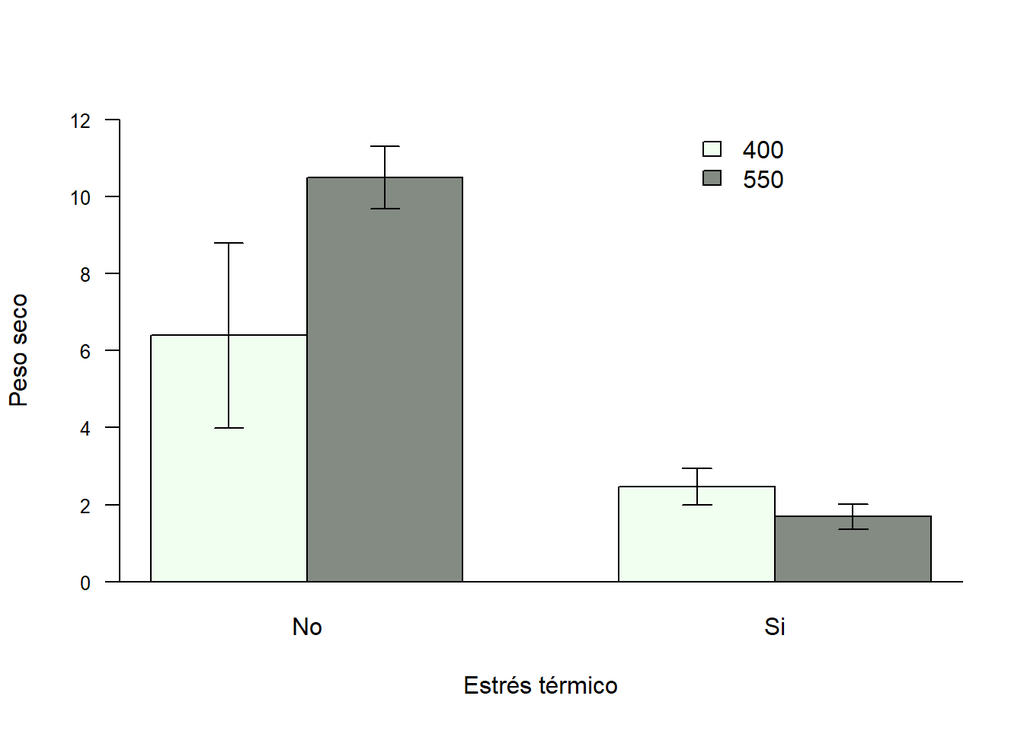

```r
bargraph.CI(x.factor = ET, response = PS, group = CO2,
            ylim = c(0,12), legend = T,
            data = SEM_Alim,  col= c("honeydew","honeydew4"),
            las=1, xlab="Estrés térmico",
            ylab= "Peso seco",
            cex.axis=0.8);abline(h=0)
```

Los parámetros a modificar son los mismos que vimos anteriormente para los gráficos de puntos.

### geom_col (ggplot2)

**Ggplot2** nos ofrece dos geoms para hacer gráficos de barras (`geom_col` y `geom_bar`). Utilizaremos en este taller únicamente geom_col.

Entonces, para realizar el mismo gráfico que hicimos con `bargraph.CI`, debemos calcular la media y el error estándar de la variable PS de semillas:

```r
SEM_Alim %>% select(CO2, ET, PS) %>% # seleccionamos las columnas involucradas
  group_by(CO2, ET) %>% # definimos criterios de agrupamiento
  summarise_all(list(mean,se)) # pedimos media y error estándar
```

```
## # A tibble: 4 × 4
## # Groups:   CO2 [2]
##   CO2   ET      fn1   fn2
##   <fct> <chr> <dbl> <dbl>
## 1 400   No     6.39 2.41
## 2 400   Si     2.47 0.476
## 3 550   No    10.5  0.811
## 4 550   Si     1.69 0.329
```

Vemos que incorpora las columnas *fn1* (que tiene los valores de las medias) y *fn2* (con los errores estándares). A estos comandos creados se les anexa el gráfico:

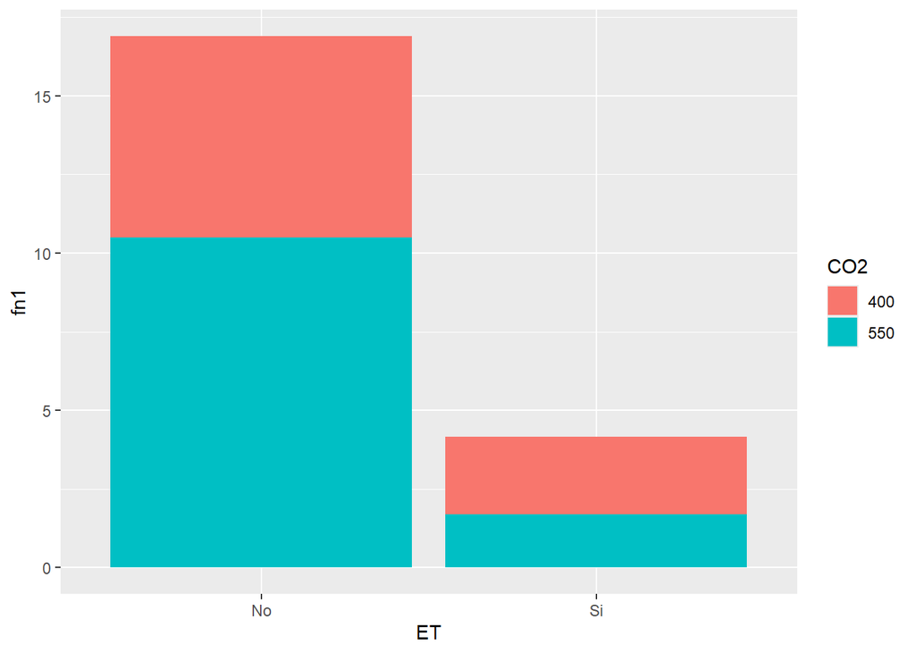

```r
SEM_Alim %>% select(CO2, ET, PS) %>%
  group_by(CO2, ET) %>%
  summarise_all(list(mean,se)) %>%
  ggplot(aes(ET, fn1,
             fill=CO2))+ # en este caso el parámetro de color lo define fill
  geom_col()
```

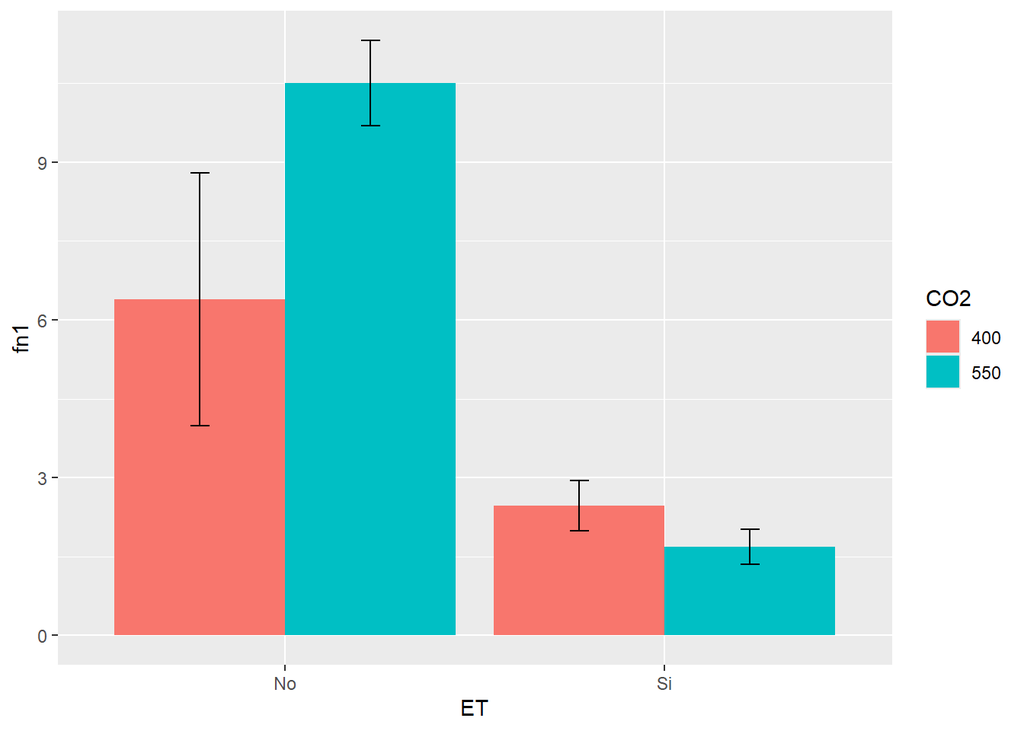

```r
G3 <- SEM_Alim %>% select(CO2, ET, PS) %>%
  group_by(CO2, ET) %>%
  summarise_all(list(mean,se)) %>%
  ggplot(aes(ET, fn1, fill=CO2))+
  geom_col(position = "dodge") +
  geom_errorbar(aes(ymin=fn1-fn2, ymax=fn1+fn2), width=.1,
                position = position_dodge(.9))
G3
```

Una alternativa para no tener que realizar manualmente la transformación de la base de datos cuando queremos graficar medias y desvíos es usar `stat_summary`. Esta función tiene una nomenclatura algo distinta a las otras y permite especificar diferentes geoms. Veamos para realizar el último gráfico:

```r
ggplot(SEM_Alim, aes(ET, PS, fill=CO2))+
  stat_summary(fun=mean, geom="col",
               position = position_dodge(0.9)) +
  stat_summary(fun.data=mean_se, geom ='errorbar', width=0.2,
               position = position_dodge(0.9))
```

[output not shown]

Sin embargo, si queremos agregar las letras del Tukey realizado, será más adecuado hacerlo con el cálculo previo de medias y error estándar. Esto es así ya que nos permite ubicar adecuadamente las letras en la altura correspondiente a cada columna. Las letras las incorporaremos de forma manual con un nuevo geom, el *geom_text*:

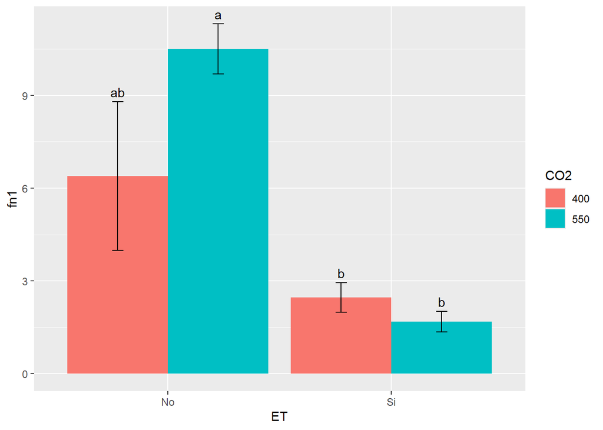

```r
G3 + geom_text(aes(y = fn1 + fn2,
                label= c("ab", "b", "a", "b")),
                position=position_dodge(0.9),
                vjust=-.5) # ajuste vertical de la posición
```

### Gráfico de barras apiladas y apilado porcentual

```r
ALIM$Organo <- factor(ALIM$Organo,
                        levels = c("Tallo","Hoja","Vaina","Semilla"))

library(plyr)
ALIM %>% select(Organo, ET, PS) %>%
  group_by(ET, Organo) %>%
  summarise_all(list(mean_se)) %>%
  ungroup() %>%
  group_by(ET) %>%
  mutate(percent_PS =  PS$y/ sum(PS$y) * 100,
         label_y= cumsum(percent_PS))
```

```
## # A tibble: 8 × 5
## # Groups:   ET [2]
##   ET    Organo   PS$y $ymin $ymax percent_PS label_y
##   <chr> <fct>   <dbl> <dbl> <dbl>      <dbl>   <dbl>
## 1 No    Tallo    4.68  4.12  5.24      11.0     11.0
## 2 No    Hoja     9.74  8.75 10.7       22.9     33.9
## 3 No    Vaina    4.36  3.62  5.11      10.2     44.1
## 4 No    Semilla  8.45  6.99  9.91      19.8     63.9
## 5 Si    Tallo    2.96  2.79  3.12       6.94    70.9
## 6 Si    Hoja     8.63  8.30  8.96      20.3     91.1
## 7 Si    Vaina    1.7   1.55  1.85       3.99    95.1
## 8 Si    Semilla  2.08  1.76  2.39       4.88   100
```

```r
ALIM_apilado <- ALIM %>% select(Organo, ET, PS) %>%
  group_by(ET, Organo) %>%
  summarise_all(funs(mean,se)) %>%
  ddply(c("ET"), transform,
        percent_PS =  mean/ sum(mean) * 100) %>%
  ddply(c("ET"), transform, label_y=cumsum(mean)) %>%
  ddply(c("ET"), transform, label_y_perc=cumsum(percent_PS)) %>%
  mutate(Organo=factor(Organo, levels=c("Semilla", "Vaina",
                                             "Hoja", "Tallo")))
```

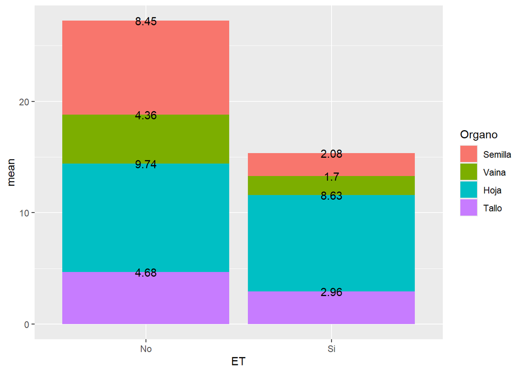

```r
G4 <- ALIM_apilado %>%
ggplot(aes(ET, mean, fill=Organo))+
  geom_col() +
  geom_text(aes(label=round(mean, 2), y = label_y)) ; G4
```

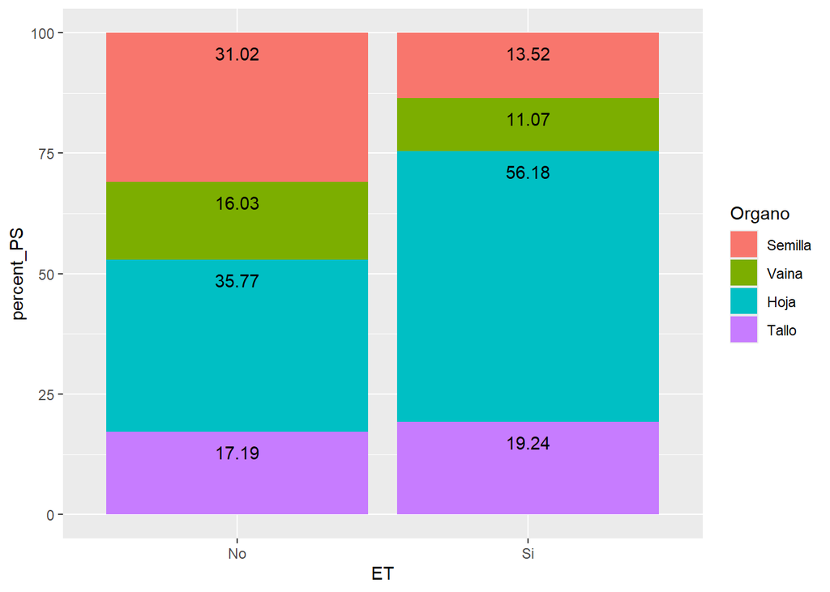

```r
G5 <- ALIM_apilado %>%
  ggplot(aes(ET, percent_PS, fill=Organo))+
  geom_col() +
  geom_text(aes(label=round(percent_PS, 2), y = label_y_perc), vjust=2) ; G5
```

## Boxplot

Los gráficos tipo boxplot también son formas frecuentes de presentar variables numéricas con distintos factores de clasificación. Veremos algunas formas de hacerlo.

### Función boxplot

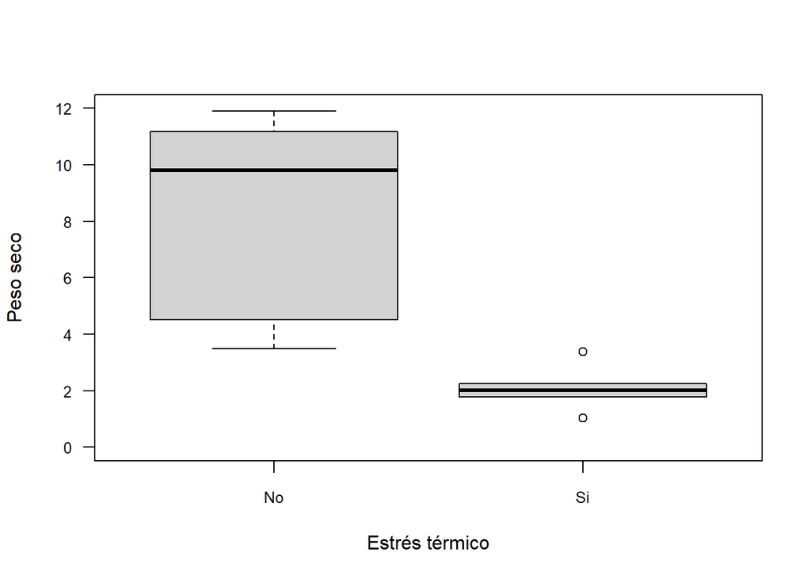

```r
boxplot(PS~ET, data = SEM_Alim,
        ylim = c(0,12),
        xlab="Estrés térmico",
        ylab= "Peso seco",
        las=1, cex.axis=0.8)
```

### geom_boxplot

El paquete **ggplot2** nos ofrece una vez maś una forma muy versátil de crear gráficos de cajas. La función en cuestión es `geom_boxplot` que, a diferencias de `geom_col`, no requiere que realicemos ningún cálculo previo. De esta manera podemos generar un gráfico con un par de líneas de código:

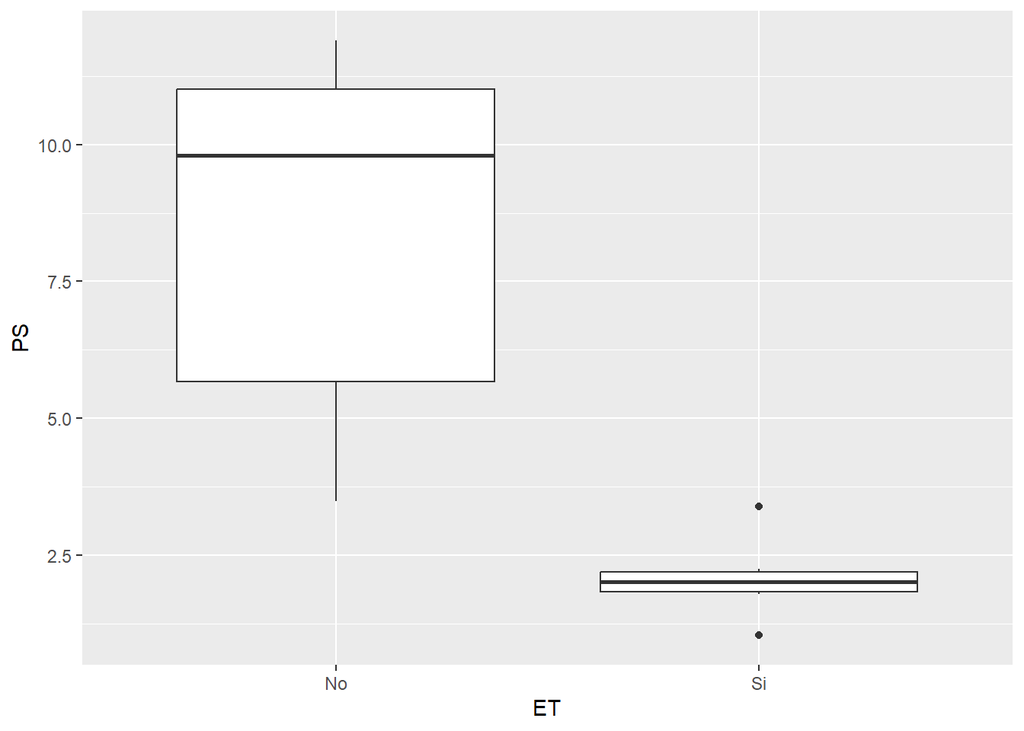

```r
ggplot(SEM_Alim, aes(ET, PS))+
  geom_boxplot()
```

Si vemos con atención a este gráfico le faltan una serie de cosas que podrían mejorarlo. Por un lado, los extremos de los cuartiles no tienen la marca de final, sino que simplemente termina la línea. Sumado a esto, podría interesarnos agregar el valor de la media, que no figura en el gráfico. Veamos como incorporarlos con la función ya vista `stat_summary`:

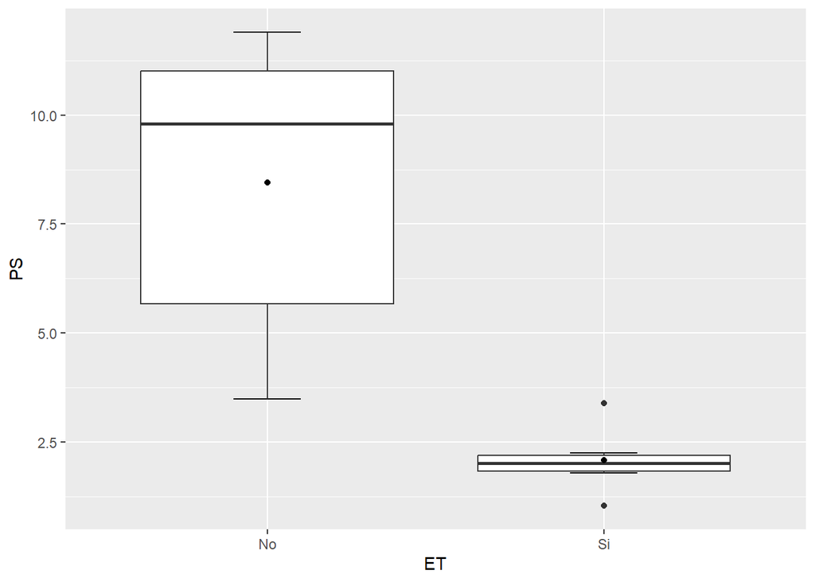

```r
ggplot(SEM_Alim, aes(ET, PS))+
  stat_boxplot(geom ='errorbar', width=0.2)+ #debemos colocarlo primero para que quede al fondo
  geom_boxplot() +
  stat_summary(fun=mean, geom="point")
```

## Actividad 5

Realice un gráfico de barras y un gráfico de cajas donde demuestre los resultados de los ANOVA realizados en la actividad 4.

Volver al inicio